# Bandas Coreanas

Aline Ramos, Juliana Rosa, Rayssa Lorrane

29/10/2021

[figure not shown]

Universidade de Brasília (UnB)

Instituto de Exatas (IE)  
Departamento de Estatística (EST)  
Computação em Estatística 2- 2021.1  
Professor: Eduardo Monteiro de Castro Gomes

# 1 Dicionário do *Kpop*

- *Hallyu:* movimento de expansão da cultura coreana;
- *Kpop:* música pop coreana;
- *idol:* artista de *kpop*;
- *debut:* primeiro lançamento do *idol* ou da banda;
- *comeback:* primeiro lançamento do novo álbum de um *idol* ou de uma banda;
- *rookie/ trainee:* artista que ainda não *debutou*, ainda está em treinamento;
- *MV:* vídeo clipe de uma música;
- *bias:* seu artista preferido da banda;
- *maknae:* membro mais novo do grupo.

# 2 Introdução

Até a década de 80, os sul-coreanos ainda consumiam em massa os entretenimentos europeus e norte-americanos. Foi então que o governo da Coréia do Sul passou a investir na produção, e posteriormente exportação, de músicas, peças cinematográficas e gastronomia local. Assim, começou a ganhar força um movimento de valorização da cultura nacional: a “Onda Coreana” ou “Hallyu”, que teve forte impacto inicial no Japão, na China e no Sudeste da Ásia.  
Uma parte chave desse movimento foi o *kpop*, que se tornou sensação entre os jovens coreanos, se espalhando depois entre as demais faixas etárias. Nos últimos anos esse estilo musical passou a se destacar no cenário internacional, criando uma grande base de fãs principalmente no Brasil e nos Estados Unidos.  
Este trabalho tem como objetivo investigar algumas características dos grupos e dos cantores de *kpop*. Foram usadas como motivação as seguintes perguntas de pesquisa:  
1- Qual foi o desenvolvimento do *kpop* ao longo dos anos? Há uma diferença no crescimento das bandas masculinas e femininas?  
2- Quais são a maiores empresas de *kpop*?  
3- Quantos membros as bandas costumam ter? Isso mudou ao longo dos anos? Existem outras variáveis que influenciam nisso?  
4- Existem mais bandas femininas ou masculinas ativas nos dias de hoje?  
5- O número de membros dentro de uma banda específica costuma mudar? É mais comum que esse número aumente ou diminua?  
6- As bandas costumam ter um nome para o seu fanclub?  
7- Os *idols*, em geral, estão em que faixa etária? Existe diferença entre as idades de *idols* ativos e inativos?  
8- Quais são as nacionalidades mais presentes de *idols* estrangeiros (não-coreanos)?  
9- Qual é a distribuição dos pesos e alturas dos *idols*?  
10- É comum que *idols* mudem de uma banda para outra?

```r
#Carregando pacotes necessários
library(ggplot2)
library(dplyr)
library(readxl)
library(lubridate)
library(kableExtra)
#Importando dados
#Já determinando os tipos das variáveis
girlgroups <- read_xlsx("girlgroups.xlsx", col_types=c("text", "text", "text", "text", "date", "text", "numeric", "numeric", "text", "text"))

boygroups <- read_xlsx("boygroups.xlsx", col_types=c("text", "text", "text", "text", "date", "text", "numeric", "numeric", "text", "text"))

female_idols <- read_xlsx("female_idols.xlsx", col_types=c("text", "text", "text", "text", "text", "date", "text", "text", "text", "numeric", "numeric", "text", "text", "text", "text", "text", "text"))

male_idols <- read_xlsx("male_idols.xlsx", col_types=c("text", "text", "text", "text", "text", "date", "text", "text", "text", "numeric", "numeric", "text", "text", "text", "text", "text", "text"))
```

```r
#Excluindo colunas que não interessam
girlgroups <- girlgroups%>%
  select(-Profile,-`Korean Name`)

boygroups <- boygroups%>%
  select(-Profile, -`Korean Name`)

female_idols <- female_idols%>%
  select(-Profile, -`Korean Name`, -`Korean Stage Name`, -`Other Group`, -`Position`, -`Instagram`, -`Twitter`)

male_idols <- male_idols%>%
  select(-Profile, -`Korean Name`, -`Korean Stage Name`, -`Other Group`, -`Position`, -`Instagram`, -`Twitter`)
```

```r
#Deletando linhas vazias
female_idols <- female_idols[!(is.na(female_idols$`Stage Name`)), ]

male_idols <- male_idols[!(is.na(male_idols$`Stage Name`)), ]
```

```r
#Juntando dados para criar um dataframe com todas as bandas
girlgroups <- girlgroups%>%
  mutate(Type="Grupos Femininos")

boygroups <- boygroups%>%
  mutate(Type="Grupos Masculinos")

kpopgroups <- rbind(girlgroups, boygroups)
```

```r
#Juntando os dados para criar um dataframe com todos os idols
female_idols <- female_idols%>%
  mutate(Sex="F")

male_idols <- male_idols%>%
  mutate(Sex="M")

idols <- rbind(female_idols, male_idols)
```

# 3 Evolução do *Kpop*

```r
#Vendo o número de bandas que debutaram em cada ano
table(year(girlgroups$Debut))
```

```
##
## 1997 2001 2005 2006 2007 2008 2009 2010 2011 2012 2013 2014 2015 2016 2017 2018
##    2    1    2    1    4    1    7    4   10   13    6   13   12   17   23   24
## 2019 2020 2021
##   18   20    4
```

```r
table(year(boygroups$Debut))
```

```
##
## 1995 1996 1997 1998 1999 2003 2004 2005 2006 2007 2008 2009 2010 2011 2012 2013
##    1    1    1    1    2    1    2    2    1    3    4    2    8    7   13    6
## 2014 2015 2016 2017 2018 2019 2020 2021
##   15   12   12   26   11   24   22    5
```

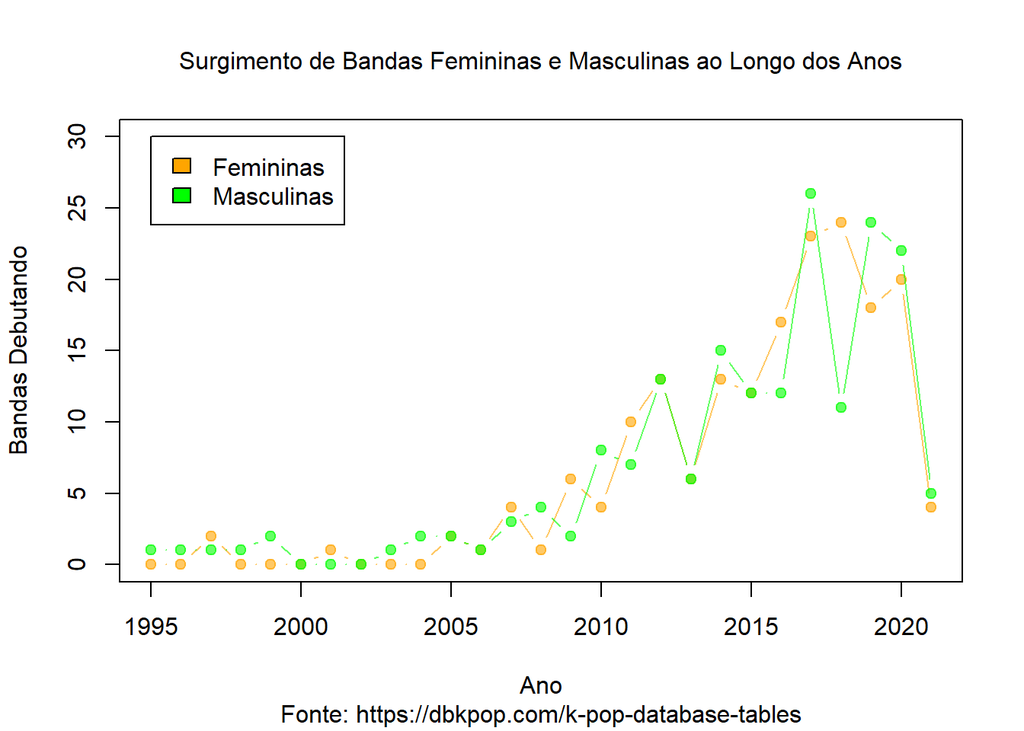

```r
#Gráfico do número de bandas novas ao longo dos anos
plot(x=c(1995, 1996, 1997, 1998, 1999, 2000, 2001, 2002, 2003, 2004, 2005, 2006, 2007, 2008, 2009, 2010, 2011, 2012, 2013, 2014, 2015, 2016, 2017, 2018, 2019, 2020, 2021), y=c(0, 0, 2, 0, 0, 0, 1, 0, 0, 0, 2, 1, 4, 1, 6, 4, 10, 13, 6, 13, 12, 17, 23, 24, 18, 20, 4), type="b", pch=19, xlab="Ano",
     ylab="Bandas Debutando", main="Surgimento de Bandas Femininas e Masculinas ao Longo dos Anos", ylim=c(0, 30), col=alpha("orange", 0.6), cex.main=1, font.main=1, sub="Fonte: https://dbkpop.com/k-pop-database-tables")
lines(c(1995, 1996, 1997, 1998, 1999, 2000, 2001, 2002, 2003, 2004, 2005, 2006, 2007, 2008, 2009, 2010, 2011, 2012, 2013, 2014, 2015, 2016, 2017, 2018, 2019, 2020, 2021), y=c(1, 1, 1, 1, 2, 0, 0, 0, 1, 2, 2, 1, 3, 4, 2, 8, 7, 13, 6, 15, 12, 12, 26, 11, 24, 22, 5), type="b", pch=19, col=alpha("green", 0.6))

legend(1995, 30, c("Femininas", "Masculinas"), fill=c("orange", "green"))
```

# 4 Maiores Empresas

```r
#Checando quais são as maiores empresas (que têm mais de 3 bandas)
table(kpopgroups$Company)[table(kpopgroups$Company)>3]
```

```
##
##     Big Hit      Chrome        Cube         DSP         FNC         JYP
##           5           4           5           5           8           9
##       Maroo         MBK      Pledis         RBW          SM Star Empire
##           4           5           4           4          14           4
##    Starship   TOP Media          TS     Woollim          YG
##           5           4           4           5           6
```

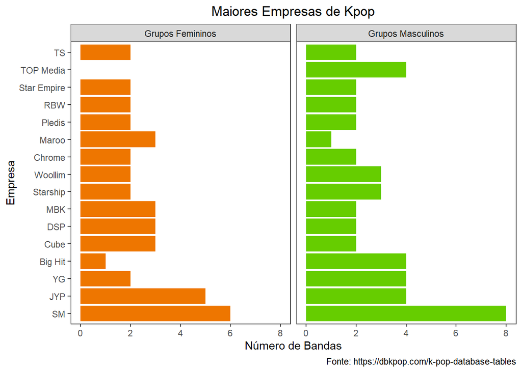

```r
#Organizando por frequência
kpopgroups$Company = factor(kpopgroups$Company,levels=names(sort(table(kpopgroups$Company), decreasing=TRUE)))

#Gráfico do número de bandas por empresa (para as maiores empresas)
big_companies <- c("Big Hit", "Chrome", "Cube", "DSP", "JYP", "Maroo", "MBK", "Pledis", "RBW", "SM", "Star Empire", "Starship", "TOP Media", "TS", "Woollim", "YG")

ggplot(kpopgroups%>%filter(Company %in% big_companies))+
  geom_bar(aes(Company, fill=Type))+
  coord_flip()+
  facet_wrap(~Type)+
  theme_test()+
  theme(legend.position="none", plot.title = element_text(hjust=.5))+
  labs(y="Número de Bandas", x="Empresa", title="Maiores Empresas de Kpop", caption="Fonte: https://dbkpop.com/k-pop-database-tables")+
  scale_fill_manual(values = c("darkorange2", "chartreuse3"))
```

O gráfico acima apresenta as empresas do *kpop* que possuem mais de 3 bandas. Na Coréia do Sul existem três empresas de grande destaque na música pop: SM, JYP e YG. Essas três empresas são conhecidas como “BIG 3” e costumam lançar mais bandas e fazer maior sucesso nesse ramo. De fato, pode-se observar que elas aparecem na base do gráfico com 14, 9 e 6 bandas, respectivamente. Logo em seguida aparece a empresa Big Hit que tem crescido muito nos últimos anos após o sucesso internacional do grupo BTS. Percebe-se também que as maiores empresas costumam lançar grupos masculinos com maior frequência.

```r
#Olhando de perto as bandas da Big Hit (empresa do BTS)
kpopgroups%>%filter(Company=="Big Hit")
```

```
## # A tibble: 5 × 9
##   Name   Short  Debut               Company Members Orig.…¹ Fancl…² Active Type
##   <chr>  <chr>  <dttm>              <fct>     <dbl>   <dbl> <chr>   <chr>  <chr>
## 1 GLAM   <NA>   2012-07-16 00:00:00 Big Hit       4       4 <NA>    No     Grup…
## 2 8Eight <NA>   2007-09-06 00:00:00 Big Hit       3       3 Sweet … No     Grup…
## 3 BTS    Bangt… 2013-06-13 00:00:00 Big Hit       7       7 ARMY    Yes    Grup…
## 4 Homme  <NA>   2010-06-28 00:00:00 Big Hit       2       2 <NA>    No     Grup…
## 5 TXT    <NA>   2019-03-04 00:00:00 Big Hit       5       5 <NA>    Yes    Grup…
## # … with abbreviated variable names ¹`Orig. Memb.`, ²`Fanclub Name`
```

# 5 Número de Membros

```r
#Teste de normalidade
#H0) O número de membros é normalmente distribuído.
shapiro.test(kpopgroups$Members)
```

```
##
##  Shapiro-Wilk normality test
##
## data:  kpopgroups$Members
## W = 0.86424, p-value < 2.2e-16
```

Foi realizado o teste de Shapiro-Wilk para verificar se o número de membros nas bandas se distribui normalmente. O resultado foi de uma estatística de teste de 0.86. Como a estatística W não está suficientemente próxima de 1 para indicar normalidade, rejeita-se a hipótese nula.

```r
#Vendo a média e a mediana do número de membros
mean(kpopgroups$Members)
```

```
## [1] 5.563187
```

```r
median(kpopgroups$Members)
```

```
## [1] 5
```

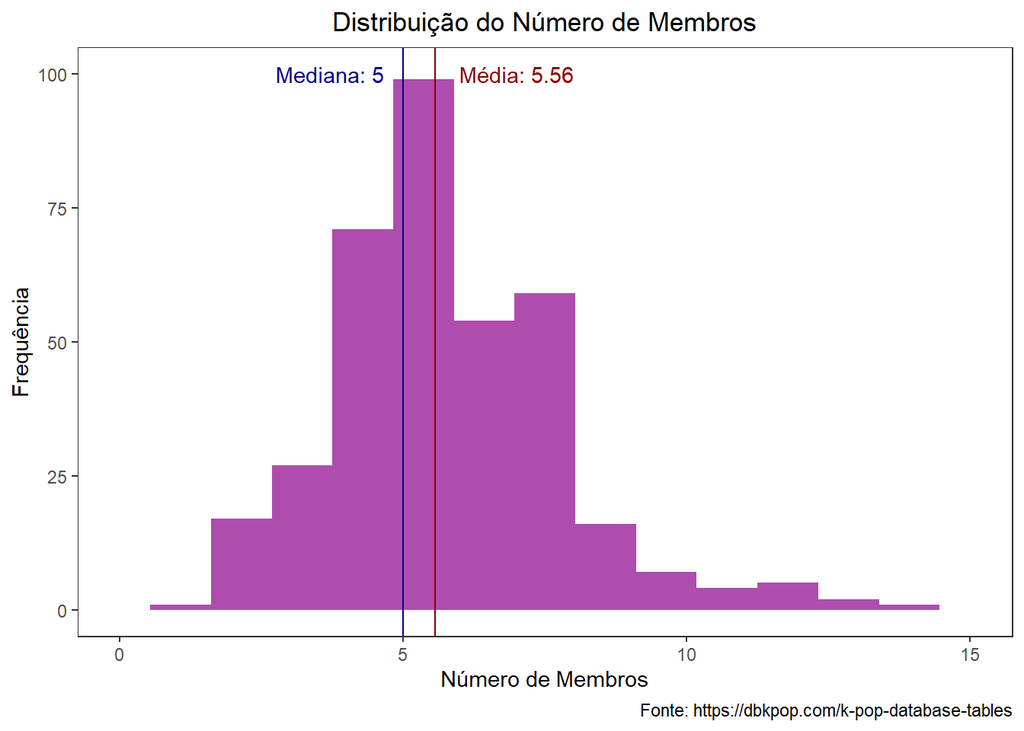

```r
#Gráfico para a distribuição do número de membros
ggplot(kpopgroups)+
  geom_histogram(aes(Members), bins=15, fill="darkmagenta", alpha=0.7)+
  geom_vline(xintercept=mean(kpopgroups$Members), color="darkred")+
  geom_vline(xintercept=median(kpopgroups$Members), color="darkblue")+
  annotate("text", x=3.7, y=100, label= "Mediana: 5", color="darkblue")+
  annotate("text", x=7, y=100, label= "Média: 5.56", color="darkred")+
  theme_test()+
  xlim(0, 15)+
  labs(x="Número de Membros", y="Frequência", title="Distribuição do Número de Membros", caption="Fonte: https://dbkpop.com/k-pop-database-tables")+
  theme(plot.title = element_text(hjust=.5))
```

No histograma acima, é possível observar que a distribuição dessa variável é assimétrica à direita, reforçando a rejeição da normal como modelo. Também é visível que o número mais comum de membros em uma banda é 5, o que reflete no valor da mediana. A média também está próxima desse valor, mas um pouco acima (5.56) por causa da assimetria mencionada. O gráfico indica que é incomum ter menos de 4 ou mais de 10 membros em uma banda.

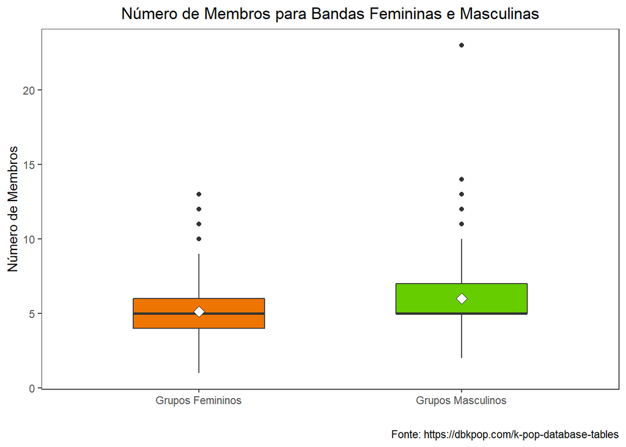

```r
#Gráfico para número de membros- feminino vs masculino
ggplot(kpopgroups, aes(x = Type, y = Members))+
geom_boxplot(fill = c("darkorange2", "chartreuse3"), width = 0.5) + theme_test()+
    stat_summary(fun = "mean", geom="point", shape=23, size=3, fill="white") +
  labs(x="", y="Número de Membros", title="Número de Membros para Bandas Femininas e Masculinas", caption="Fonte: https://dbkpop.com/k-pop-database-tables")+
  theme(plot.title = element_text(hjust=.5))
```

```r
#Medidas Descritivas para o número de membros

#Grupos femininos
medidasG <- data.frame( girlgroups%>%
  summarize(media=mean(Members), min=min(Members), q1=quantile(Members, 0.25),
            mediana=median(Members), q3=quantile(Members, 0.75), max=max(Members),
            iiq=IQR(Members), variancia=var(Members),
            dp=sd(Members), cv=sd(Members)/mean(Members)))

#Grupos masculinos
medidasB <- data.frame(boygroups%>%
  summarize(media=mean(Members), min=min(Members), q1=quantile(Members, 0.25),
            mediana=median(Members), q3=quantile(Members, 0.75), max=max(Members),
            iiq=IQR(Members), variancia=var(Members),
            dp=sd(Members), cv=sd(Members)/mean(Members)))

#Jntando as informações em uma só tabela
medidasJuntas <- bind_rows(medidasG,medidasB)
medidasJuntas <- round(medidasJuntas, 2)

#Tabela das medidas descritivas do número de membros
t(medidasJuntas) %>%
  kbl(caption = "Tabela 1: Medidas Descritivas para o Número de Membros.", col.names=c("Grupos Femininos", "Grupos Masculinos"), align=c("c", "c")) %>%
  kable_classic(full_width = F, html_font = "Cambria", position="left")
```

Tabela 1: Medidas Descritivas para o Número de Membros.

|  | Grupos Femininos | Grupos Masculinos |
| --- | --- | --- |
| media | 5.13 | 6.00 |
| min | 1.00 | 2.00 |
| q1 | 4.00 | 5.00 |
| mediana | 5.00 | 5.00 |
| q3 | 6.00 | 7.00 |
| max | 13.00 | 23.00 |
| iiq | 2.00 | 2.00 |
| variancia | 3.77 | 6.54 |
| dp | 1.94 | 2.56 |
| cv | 0.38 | 0.43 |

Fonte: [dbkpop](https://dbkpop.com/k-pop-database-tables)  
Os boxplots mostram a diferença no tamanho das bandas femininas e masculinas: os grupos masculinos costumam ter mais membros. Com exceção da mediana, que é 5 para ambos os tipos de banda, todas as medidas de posição são mais altas para os grupos masculinos. A média também é bem mais elevada, o que provavelmente está relacionado ao outlier de mais de 20 membros que existe entre as bandas masculinas (o grupo NCT). Pelo coeficiente de variação, nota-se também que a distribuição tem menor variabilidade para as bandas femininas.

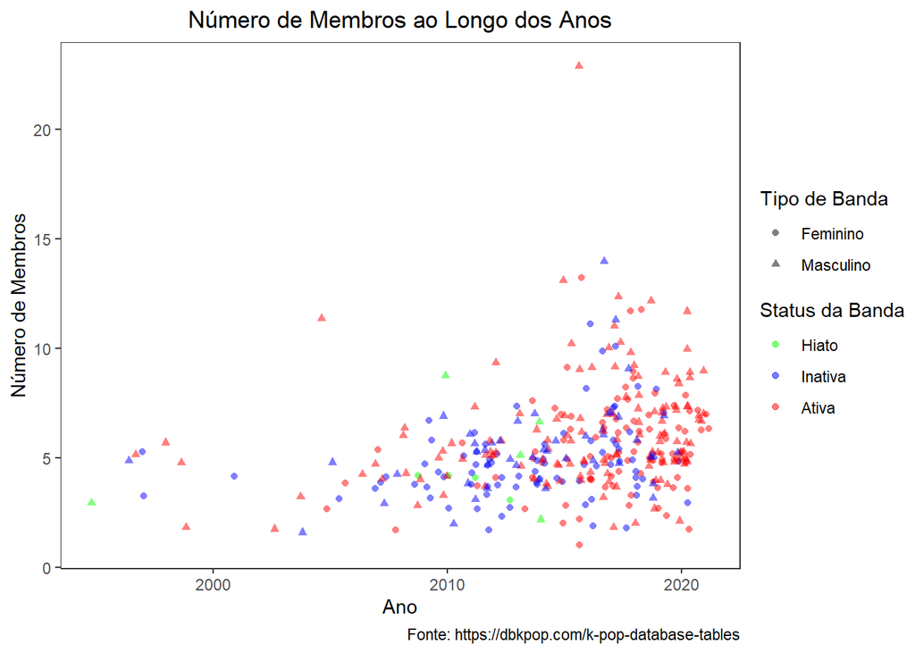

```r
#Gráfico ano vs membros
ggplot(kpopgroups)+
  geom_jitter(aes(year(Debut), Members, color=Active, shape=Type), alpha=0.5)+
  theme_test()+
  labs(x="Ano", y="Número de Membros", title="Número de Membros ao Longo dos Anos", caption="Fonte: https://dbkpop.com/k-pop-database-tables")+
  scale_color_manual(values = c("green", "blue", "red"), labels=c("Hiato", "Inativa", "Ativa"))+
  scale_shape_manual(values=c(16, 17), labels=c("Feminino", "Masculino"))+
  guides(color = guide_legend(title = "Status da Banda"), shape=guide_legend(title="Tipo de Banda"))+
  theme(plot.title = element_text(hjust=.5))
```

O diagrama acima evidencia o crescimento do *kpop* nos últimos anos, já que a quantidade de bandas surgindo nos anos mais recentes é bem maior do que anteriormente. Também é possível perceber certo aumento na quantidade de membros nas bandas. Além disso, grupos femininos passaram a ganhar maior espaço na indústria. O que surpreende é a mistura das cores por todo o gráfico, pois o esperado seria que as bandas mais antigas estivessem inativas e as mais novas ativas. Na verdade, isso ocorre porque a fama é mais importante em determinar o status da banda do que seu tempo de atividade. Se um grupo faz muito sucesso, ele continua ativo mesmo depois de anos de carreira. Já os grupos que não fazem sucesso são logo desligados mesmo quando são relativamente novos.

```r
#Outlier
kpopgroups%>%filter(Members>15)
```

```
## # A tibble: 1 × 9
##   Name  Short Debut               Company Members Orig. M…¹ Fancl…² Active Type
##   <chr> <chr> <dttm>              <fct>     <dbl>     <dbl> <chr>   <chr>  <chr>
## 1 NCT   <NA>  2016-04-09 00:00:00 SM           23        23 NCTzen  Yes    Grup…
## # … with abbreviated variable names ¹`Orig. Memb.`, ²`Fanclub Name`
```

# 6 Bandas Ativas

```r
#Teste de independência
#HO) O tipo de banda não interfere no seu status.
chisq.test(kpopgroups$Type, kpopgroups$Active)
```

```
##
##  Pearson's Chi-squared test
##
## data:  kpopgroups$Type and kpopgroups$Active
## X-squared = 15.633, df = 2, p-value = 0.0004031
```

Foi realizado um teste de independência para verificar a relação entre o tipo de banda (feminina/ masculina) e seu status (ativa/ inativa). Com um p-valor de 0.0004, rejeita-se a hipótese de independência e conclui-se que essas duas variáveis estão associadas.

```r
#Coeficiente de Contingencia Modificado
qui_quadrado <- as.numeric(chisq.test(kpopgroups$Type, kpopgroups$Active)[1])
(2*qui_quadrado/(364+qui_quadrado))**0.5
```

```
## [1] 0.2869781
```

O coeficiente de contingência modificado assumiu valor de 0.29, indicando que a associação mencionada é de fraca a moderada.

```r
#Tabela de contingência para o status vs o tipo da banda
tipo_banda <- kpopgroups[,c("Type","Active")] %>%
  table() %>%
  prop.table(margin=1)
tipo_banda <- round(tipo_banda, 2)

tipo_banda%>%
  kbl(caption = "Tabela 2: Status das Bandas.", col.names=c("Hiato", "Inativos", "Ativos"), align=rep('c', 3)) %>%
  kable_classic(full_width = F, html_font = "Cambria", position="left")
```

Tabela 2: Status das Bandas.

|  | Hiato | Inativos | Ativos |
| --- | --- | --- | --- |
| Grupos Femininos | 0.02 | 0.45 | 0.53 |
| Grupos Masculinos | 0.03 | 0.25 | 0.72 |

Fonte: [dbkpop](https://dbkpop.com/k-pop-database-tables)  
A tabela 2 indica poucas bandas em hiato e uma maioria de bandas masculinas em atividade. Apenas 53% das bandas femininas continuam ativas atualmente, enquanto para as masculinas esse valor é de 72%.

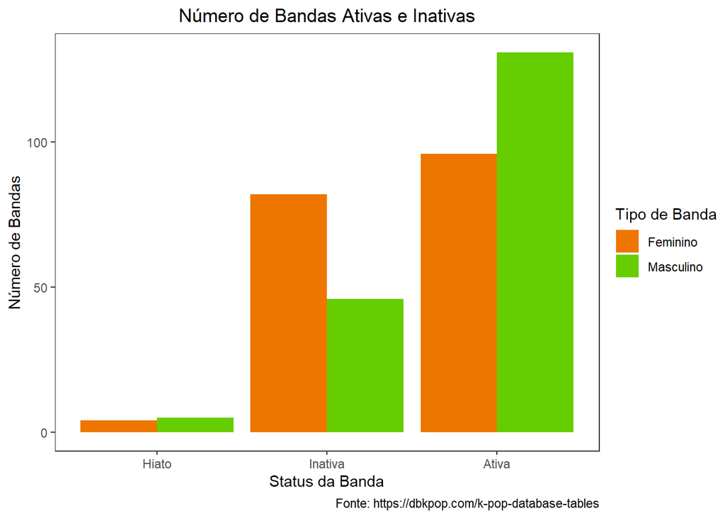

```r
#Gráfico para bandas ativas ou inativas
ggplot(kpopgroups)+
  geom_bar(aes(Active, fill=Type), position="dodge")+
  theme_test()+
  labs(x="Status da Banda", y="Número de Bandas", title="Número de Bandas Ativas e Inativas", caption="Fonte: https://dbkpop.com/k-pop-database-tables")+
  scale_fill_manual(values = c("darkorange2", "chartreuse3"), labels=c("Feminino", "Masculino"))+
  guides(fill = guide_legend(title = "Tipo de Banda"))+
  scale_x_discrete(labels=c("Hiato", "Inativa", "Ativa"))+
  theme(plot.title = element_text(hjust=.5))
```

No gráfico é evidente que, para ambos os tipos de banda, o mais comum é estar em ativa e o menos comum é estar em hiato. Também é reforçada a conclusão de que os grupos femininos costumam sair de atividade em proporção maior quando comparados aos masculinos.

# 7 Mudança nos Integrantes

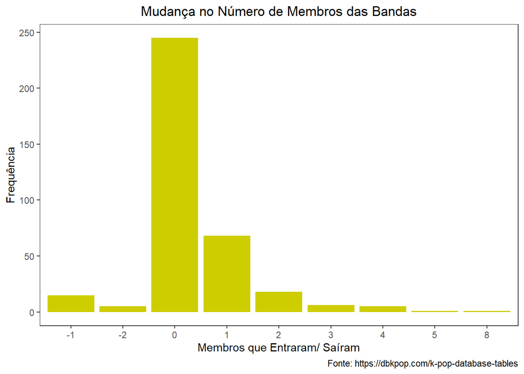

```r
#Criando uma variável que seja a diferença entre o número de membros original e o número de membros atual
kpopgroups["dif_membros"]<- kpopgroups$`Orig. Memb.` - kpopgroups$`Members`

#Gráfico de colunas para os países de origem
ggplot(kpopgroups)+ geom_bar(aes(x = as.character(dif_membros)), fill = "yellow3")+labs(title= "Mudança no Número de Membros das Bandas",x="Membros que Entraram/ Saíram", y="Frequência", caption="Fonte: https://dbkpop.com/k-pop-database-tables")+ theme_test()+theme(plot.title = element_text(hjust=.5))
```

O cálculo foi feito considerando a diferença entre o número de integrantes originais e atuais.  
Como é possível observar pelo gráfico, na grande maioria das bandas, o número de membros permanece intacto. Mas, analisando o fluxo das demais classes nota-se que é mais comum a saída de membros do que a entrada. E, dentre as categorias que representam alguma mudança no número de membros, a de maior frequência é a que representa a saída de 1 participante.

# 8 Fã-clubes

```r
#Contando o número de NA’s na variável “Fanclub Name”.
sum(is.na(kpopgroups$`Fanclub Name`))
```

```
## [1] 248
```

```r
#Total de bandas
nrow(kpopgroups)
```

```
## [1] 364
```

```r
#Tabela de proporções das bandas com ou sem nome para o fanclube
Fanclub <- data.frame(com = round((364-248)/364, 2), sem = round(248/364, 2))
Fanclub %>%
  kbl(caption = "Tabela 3: Proporção de Bandas que têm Nome para o seu Fã-clube.", col.names=c("Com Nome para o Fã-Clube", "Sem Nome para o Fã-Clube"), align=rep('c', 3)) %>%
  kable_classic(full_width = F, html_font = "Cambria", position="left")
```

Tabela 3: Proporção de Bandas que têm Nome para o seu Fã-clube.

| Com Nome para o Fã-Clube | Sem Nome para o Fã-Clube |
| --- | --- |
| 0.32 | 0.68 |

Fonte: [dbkpop](https://dbkpop.com/k-pop-database-tables)  
Ao observar o percentual de bandas que possuem nome para seu fã-clube (31.87%), é verossímil que esta não é uma característica comum à maioria dos grupos. O percentual de bandas que não carregam essa característica é mais que o dobro das que carregam.

# 9 Idades dos *Idols*

```r
#Criando variável para indicar se o idol está ativo ou não
idols$Active <- rep(NA, 1549)
for (i in 1:nrow(kpopgroups)){
  for (j in 1:nrow(idols)){
    if (!is.na(idols$Group[j])){
      if (idols$Group[j]==kpopgroups$Name[i]){
        idols$Active[j] <- kpopgroups$Active[i]
      }
    }
  }
}

for (i in 1:nrow(idols)){
  if (!is.na(idols$Active[i])){
    if (idols$Active[i]=="Yes"){
      idols$Active[i] <- "Ativo"
    }
    if (idols$Active[i]=="No"){
      idols$Active[i] <- "Inativo"
    }
  }
}
```

```r
# Criando variável idade
idols <- idols%>%
  mutate(Idade=2021-year(`Date of Birth`)) #idade aproximada
```

```r
#Teste de normalidade
#H0) a idade é normalmente distribuída.

#Filtrando só para ativos e inativos (sem NA's e Hiatos)
idols2 <- idols%>%filter(Active%in%c("Ativo", "Inativo"))

#Teste para idols ativos
shapiro.test((idols2%>%filter(Active=="Ativo"))$Idade)
```

```
##
##  Shapiro-Wilk normality test
##
## data:  (idols2 %>% filter(Active == "Ativo"))$Idade
## W = 0.95455, p-value = 3.829e-15
```

```r
#Teste para idols inativos
shapiro.test((idols2%>%filter(Active=="Inativo"))$Idade)
```

```
##
##  Shapiro-Wilk normality test
##
## data:  (idols2 %>% filter(Active == "Inativo"))$Idade
## W = 0.98458, p-value = 0.01791
```

Foram feitos dois testes de Shapiro-Wilk para checar se a distribuição das idades dos *idols* é normal. Para os cantores ativos, o teste resultou em um p-valor extremamente pequeno (na casa de 10<sup>-15</sup>), rejeitando a hipótese de normalidade. Já para os inativos, o p-valor foi mais elevado, assumindo 0.018. Para um teste com nível de significância de 5%, esse valor permite a rejeição da hipótese nula, mas tomando um nível de 1%, por exemplo, isso não é possível.

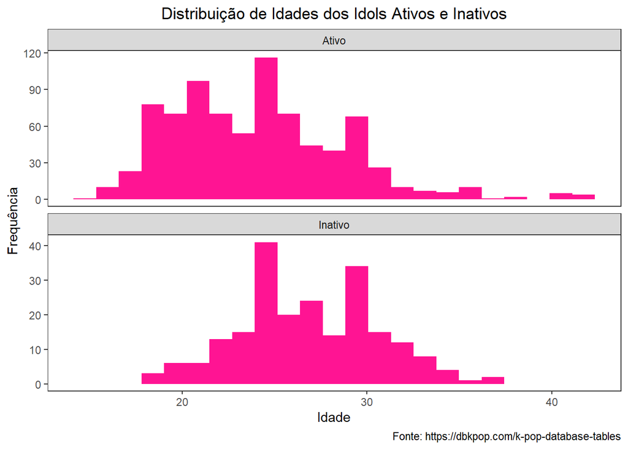

```r
#Gráfico de idades
ggplot(idols2)+
  geom_histogram(aes(Idade), bins=23, fill="deeppink1")+
  facet_wrap(~Active, scales="free_y", nrow=2)+
  theme_test()+
  labs(y="Frequência", title="Distribuição de Idades dos Idols Ativos e Inativos", caption="Fonte: https://dbkpop.com/k-pop-database-tables")+
  theme(plot.title = element_text(hjust=.5))
```

```r
#Medidas Descritivas das idades

#Para ativos
ativo <- idols2 %>%
  filter(Active=="Ativo")%>%
  summarize(media=mean(Idade), min=min(Idade), q1=quantile(Idade, 0.25),
            mediana=median(Idade), q3=quantile(Idade, 0.75), max=max(Idade),
            iiq=IQR(Idade), variancia=var(Idade),
            dp=sd(Idade), cv=sd(Idade)/mean(Idade))

#Para inativos
inativo <- idols2 %>%
  filter(Active=="Inativo")%>%
  summarize(media=mean(Idade), min=min(Idade), q1=quantile(Idade, 0.25),
            mediana=median(Idade), q3=quantile(Idade, 0.75), max=max(Idade),
            iiq=IQR(Idade), variancia=var(Idade),
            dp=sd(Idade), cv=sd(Idade)/mean(Idade))

#Jntando as informações
IdadeJuntas <- bind_rows(ativo,inativo)
IdadeJuntas <- round(IdadeJuntas, 2)

#Tabela de medidas descritivas para as idades
t(IdadeJuntas) %>%
  kbl(caption = "Tabela 4: Medidas Descritivas das Idades.", align=rep('c', 2), col.names=c("Idols Ativos", "Idols Inativos")) %>%
  kable_classic(full_width = F, html_font = "Cambria", position="left")
```

Tabela 4: Medidas Descritivas das Idades.

|  | Idols Ativos | Idols Inativos |
| --- | --- | --- |
| media | 24.15 | 26.91 |
| min | 15.00 | 19.00 |
| q1 | 21.00 | 24.00 |
| mediana | 24.00 | 27.00 |
| q3 | 27.00 | 30.00 |
| max | 42.00 | 37.00 |
| iiq | 6.00 | 6.00 |
| variancia | 21.46 | 14.11 |
| dp | 4.63 | 3.76 |
| cv | 0.19 | 0.14 |

Fonte: [dbkpop](https://dbkpop.com/k-pop-database-tables)  
De fato, quase todas as medidas de posição são mais altas para os *idols* inativos. A única exceção é o valor máximo que, curiosamente, é mais alto para os ativos, pois existem cantores de 42 anos ainda em atividade. Por fim, as idades dos *idols* ativos são mais variáveis, como se pode ver a partir do coeficiente de variação (0.19 vs 0.14).

```r
#Idols de 42 anos
idols2%>%filter(Idade==42)
```

```
## # A tibble: 4 × 13
##   `Stage Name` Full Na…¹ `Date of Birth`     Group Country Secon…² Height Weight
##   <chr>        <chr>     <dttm>              <chr> <chr>   <chr>    <dbl>  <dbl>
## 1 Dongwan      Kim Dong… 1979-11-21 00:00:00 Shin… South … <NA>       173     68
## 2 Eric         Moon Jun… 1979-02-16 00:00:00 Shin… South … <NA>       180     70
## 3 Minwoo       Lee Minw… 1979-07-28 00:00:00 Shin… South … <NA>       172     60
## 4 Shin Hyesung Jung Pil… 1979-11-27 00:00:00 Shin… South … <NA>       179     65
## # … with 5 more variables: Birthplace <chr>, `Former Group` <chr>, Sex <chr>,
## #   Active <chr>, Idade <dbl>, and abbreviated variable names ¹`Full Name`,
## #   ²`Second Country`
```

```r
#Banda dos idols de 42 anos
kpopgroups%>%filter(Name=="Shinhwa")
```

```
## # A tibble: 1 × 10
##   Name    Short Debut               Company Members Orig.…¹ Fancl…² Active Type
##   <chr>   <chr> <dttm>              <fct>     <dbl>   <dbl> <chr>   <chr>  <chr>
## 1 Shinhwa <NA>  1998-03-24 00:00:00 SM, Go…       6       6 Shinhw… Yes    Grup…
## # … with 1 more variable: dif_membros <dbl>, and abbreviated variable names
## #   ¹`Orig. Memb.`, ²`Fanclub Name`
```

# 10 *Idols* Estrangeiros

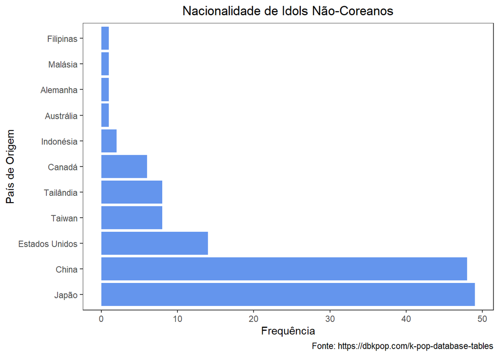

```r
#filtrar para idols que são não-coreanos
nacionalidade <- idols %>%
  filter(Country != "South Korea")

#Juntando China e Hong Kong
for (i in 1:nrow(nacionalidade)){
  if (nacionalidade$Country[i]=="Hong Kong"){
    nacionalidade$Country[i] <- "China"
  }
}

#Organizando por frequência
nacionalidade$Country = factor(nacionalidade$Country,levels=names(sort(table(nacionalidade$Country), decreasing=TRUE)))

#Gráfico de barras para as demais nacionalidades
ggplot(nacionalidade, aes(y = Country))+ geom_bar(fill = "cornflowerblue")+labs(title= "Nacionalidade de Idols Não-Coreanos",x="Frequência", y="País de Origem", caption="Fonte: https://dbkpop.com/k-pop-database-tables")+ theme_test()+theme(plot.title = element_text(hjust=.5))+
  scale_y_discrete(breaks=rev(c("Japan", "China", "USA", "Taiwan", "Thailand", "Canada", "Indonesia", "Australia", "Germany", "Malaysia", "Philippines")), labels=rev(c("Japão", "China", "Estados Unidos", "Taiwan", "Tailândia", "Canadá", "Indonésia", "Austrália", "Alemanha", "Malásia", "Filipinas")))
```

A nacionalidade de idols não-coreanos marca presença em 7 países localizados na Ásia, 2 na América do Norte, 1 na Europa e 1 na Oceania. A maior frequência de *idols* estrangeiros está concentrada na China e no Japão, ambos superando a frequência de 40 cantores. Para os demais países, a frequência diminui drasticamente, onde a maioria apresenta menos de 10 *idols*.

# 11 Pesos e Alturas dos *Idols*

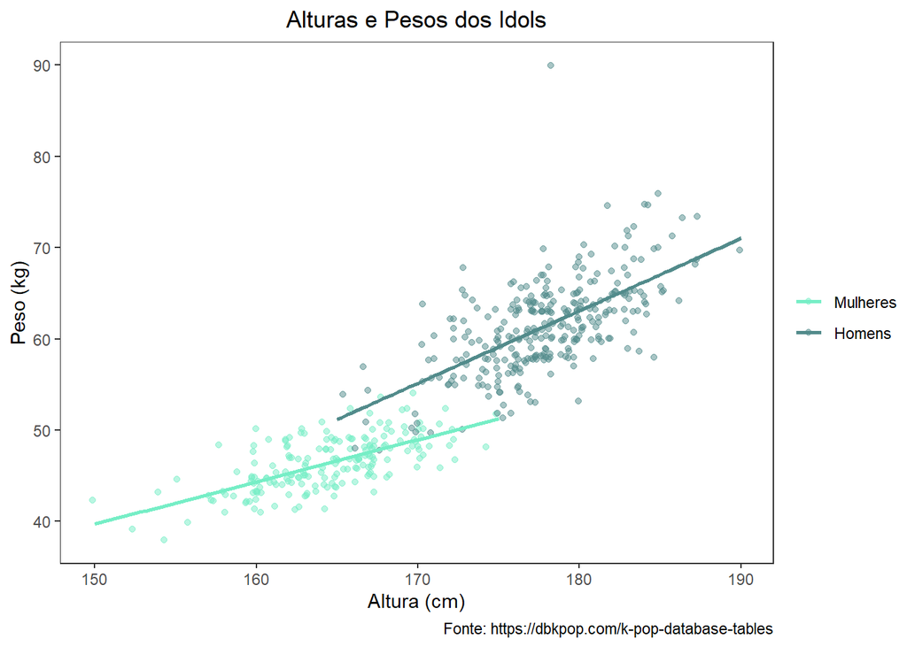

```r
#Gráfico para alturas e pesos dos idols
ggplot(idols%>%filter(Height!=0, Weight!=0), aes(Height, Weight, color=Sex))+
  geom_jitter(alpha=0.5)+
  geom_smooth(method=lm, se=FALSE, formula=y~x)+
  theme_test()+
  labs(x="Altura (cm)", y="Peso (kg)", title="Alturas e Pesos dos Idols", caption="Fonte: https://dbkpop.com/k-pop-database-tables")+
  theme(plot.title = element_text(hjust=.5))+
  scale_color_manual(values = c("aquamarine2", "darkslategray4"), labels=c("Mulheres", "Homens"))+
  guides(color = guide_legend(title = ""))
```

Como já esperado de um gráfico Peso x Altura, há uma relação positiva entre as variáveis (quando a altura aumenta, o peso também aumenta). O fator sexo também aparece da maneira esperada: homens mais altos e mais pesados do que mulheres. Uma das informações novas que podem ser retiradas do gráfico é que existem mais *idols* homens do que mulheres, o que faz sentido já que as bandas masculinas costumam ter mais membros. Além disso, as cantoras têm menor variabilidade nos pesos, refletindo a exigência no padrão de beleza feminino. Também é interessante perceber que alguns homens se misturam entre os pesos e alturas femininos.

```r
#Outlier
idols%>%filter(Weight>80)
```

```
## # A tibble: 1 × 13
##   `Stage Name` Full Na…¹ `Date of Birth`     Group Country Secon…² Height Weight
##   <chr>        <chr>     <dttm>              <chr> <chr>   <chr>    <dbl>  <dbl>
## 1 Shindong     Shin Don… 1985-09-28 00:00:00 Supe… South … <NA>       178     90
## # … with 5 more variables: Birthplace <chr>, `Former Group` <chr>, Sex <chr>,
## #   Active <chr>, Idade <dbl>, and abbreviated variable names ¹`Full Name`,
## #   ²`Second Country`
```

```r
#Mulheres:
#Testando relação linear
cor.test((female_idols%>%filter(Height!=0, Weight!=0))$Height, (female_idols%>%filter(Height!=0, Weight!=0))$Weight, method="spearman")
```

```
##
##  Spearman's rank correlation rho
##
## data:  (female_idols %>% filter(Height != 0, Weight != 0))$Height and (female_idols %>% filter(Height != 0, Weight != 0))$Weight
## S = 423082, p-value < 2.2e-16
## alternative hypothesis: true rho is not equal to 0
## sample estimates:
##       rho
## 0.6413391
```

```r
cor.test((female_idols%>%filter(Height!=0, Weight!=0))$Height, (female_idols%>%filter(Height!=0, Weight!=0))$Weight, method="pearson")
```

```
##
##  Pearson's product-moment correlation
##
## data:  (female_idols %>% filter(Height != 0, Weight != 0))$Height and (female_idols %>% filter(Height != 0, Weight != 0))$Weight
## t = 12.061, df = 190, p-value < 2.2e-16
## alternative hypothesis: true correlation is not equal to 0
## 95 percent confidence interval:
##  0.5700631 0.7318730
## sample estimates:
##       cor
## 0.6585125
```

```r
#Modelo linear
mod2 <- lm(Weight~Height, data=female_idols%>%filter(Height!=0, Weight!=0))
coef(mod2)
```

```
## (Intercept)      Height
## -29.6636609   0.4624488
```

```r
#Homens:
#Testando relação linear
cor.test((male_idols%>%filter(Height!=0, Weight!=0))$Height, (male_idols%>%filter(Height!=0, Weight!=0))$Weight, method="spearman")
```

```
##
##  Spearman's rank correlation rho
##
## data:  (male_idols %>% filter(Height != 0, Weight != 0))$Height and (male_idols %>% filter(Height != 0, Weight != 0))$Weight
## S = 1782923, p-value < 2.2e-16
## alternative hypothesis: true rho is not equal to 0
## sample estimates:
##       rho
## 0.6229587
```

```r
cor.test((male_idols%>%filter(Height!=0, Weight!=0))$Height, (male_idols%>%filter(Height!=0, Weight!=0))$Weight, method="pearson")
```

```
##
##  Pearson's product-moment correlation
##
## data:  (male_idols %>% filter(Height != 0, Weight != 0))$Height and (male_idols %>% filter(Height != 0, Weight != 0))$Weight
## t = 13.97, df = 303, p-value < 2.2e-16
## alternative hypothesis: true correlation is not equal to 0
## 95 percent confidence interval:
##  0.5524465 0.6897413
## sample estimates:
##       cor
## 0.6259195
```

```r
#Modelo linear
mod1 <- lm(Weight~Height, data=male_idols%>%filter(Height!=0, Weight!=0))
coef(mod1)
```

```
## (Intercept)      Height
## -79.7739774   0.7936558
```

Os coeficientes de Pearson e Spearman estão em torno de 0.65 para as mulheres e 0.62 para os homens, indicando que há uma correlação linear entre altura e peso em ambos os casos (mais linear para as mulheres). Ao construir o modelo de regressão linear, o valor do intercepto não é muito informativo nesse caso pois a altura ser nula seria uma situação impossível. Já os coeficientes angulares mostram que o aumento de 1 cm na altura causa, em média, um aumento de 0.46 kg no peso das mulheres e 0,79 kg no peso dos homens.

```r
#Tabela anova mulheres
anova2 <- anova(mod2)
anova2 %>%
  kbl(align="c", caption="Tabela 5: ANOVA para o Modelo Linear Peso x Altura das Mulheres.", col.names=c("FV", "SQ", "QM", "Estatística F", "P-Valor"), row.names=F)%>%
  kable_classic(full_width = F, html_font = "Cambria", position="left")
```

Tabela 5: ANOVA para o Modelo Linear Peso x Altura das Mulheres.

| FV | SQ | QM | Estatística F | P-Valor |
| --- | --- | --- | --- | --- |
| 1 | 712.7372 | 712.737230 | 145.4749 | 0 |
| 190 | 930.8826 | 4.899382 | NA | NA |

Fonte: [dbkpop](https://dbkpop.com/k-pop-database-tables)

```r
#Tabela anova homens
anova1 <- anova(mod1)
anova1 %>%
  kbl(align="c", caption="Tabela 6: ANOVA para o Modelo Linear Peso x Altura dos Homens.", col.names=c("FV", "SQ", "QM", "Estatística F", "P-Valor"), row.names=F)%>%
  kable_classic(full_width = F, html_font = "Cambria", position="left")
```

Tabela 6: ANOVA para o Modelo Linear Peso x Altura dos Homens.

| FV | SQ | QM | Estatística F | P-Valor |
| --- | --- | --- | --- | --- |
| 1 | 3167.753 | 3167.75337 | 195.1711 | 0 |
| 303 | 4917.886 | 16.23065 | NA | NA |

Fonte: [dbkpop](https://dbkpop.com/k-pop-database-tables)  
Por fim, a estatística F, disponível nas tabelas ANOVA, permite a rejeição da hipótese nula em ambos os casos. Essa hipótese é de que a coeficiente angular seria zero. Com isso, comprova-se a pertinência do modelo linear para essas variáveis.

# 12 Realocação de Cantores

```r
#Contando o número de NA’s na variável “Former Group”
sum(is.na(idols$`Former Group`))
```

```
## [1] 1324
```

```r
#Total de idols
nrow(idols)
```

```
## [1] 1549
```

```r
#Tabela das proporções dos idols que mudaram ou não de banda
Fanclub <- data.frame(Nunca = round(1324/1549, 2),Já = round((1549-1324)/1549, 2))
Fanclub <- round(Fanclub, 2)#Diminuindo as casas decimais
Fanclub %>%
  kbl(align=rep('c', 2), caption="Tabela 7: Proporção de Idols que Mudaram de Banda.", col.names=c("Nunca Mudaram", "Já Mudaram")) %>%
  kable_classic(full_width = F, html_font = "Cambria", position="left")
```

Tabela 7: Proporção de Idols que Mudaram de Banda.

| Nunca Mudaram | Já Mudaram |
| --- | --- |
| 0.85 | 0.15 |

Fonte: [dbkpop](https://dbkpop.com/k-pop-database-tables)  
Apenas 15% dos *idols* já mudaram de uma banda para outra. Um dos indicativos desse resultado é que a saída de um membro pode afetar negativamente a imagem e a popularidade do grupo.

# 13 Conclusões

A partir das análises feitas, é evidente que o *kpop* teve um grande crescimento nos últimos anos, principalmente para os grupos femininos, que antes eram menos valorizados. Também foi possível perceber que algumas empresas possuem uma espécie de monopólio na indústria.  
Sobre os grupos de *kpop*, concluiu-se que a maior parcela dos que estão em ativa são masculinos, que também são os que costumam ter mais membros. O número de integrantes em uma banda, em geral, varia entre 4 e 7, mas tem apresentado tendência de crescimento nos últimos anos. O fator mais determinante do status da banda (ativa/ inativa) é o sucesso dela, e não o seu tempo de atividade. As bandas femininas são desligadas com maior frequência, mostrando que as masculinas ainda fazem maior sucesso.  
Outras curiosidades sobre os grupos de pop coreano: o número de membros em uma banda não costuma mudar, mas quando muda geralmente é porque houve a saída de um integrante; os *idols* não costumam intercambiar muito entre diferentes grupos; a maioria das bandas não possui um nome oficial para o seu fã-clube.  
Analisando os dados pessoais dos *idols*, foi possível perceber que os que estão ativos são, em geral, mais jovens, provavelmente devido à constante entrada de *rookies* na indústria. Além disso, apesar de a maioria dos cantores ser coreana, existem também idols estrangeiros, em especial vindos da China, do Japão ou dos Estados Unidos. Por fim, os pesos dos cantores variam de 40 kg a 50 kg para as mulheres e de 55 kg a 75 kg para os homens. Já as alturas variam de 150 cm a 175 cm para as mulheres e de 170 cm a 185 cm para os homens.

# 14 Referências

Fonte de dados:  
https://dbkpop.com/db/k-pop-girlgroups  
https://dbkpop.com/db/k-pop-boybands  
https://dbkpop.com/db/female-k-pop-idols  
https://dbkpop.com/db/male-k-pop-idols  
Dicionário do *kpop:*  
https://aminoapps.com/c/universocoreano-9350942/page/blog/girias-de-k-pop/6P8r_L6ltzu6qvoGvnzvbgdPQ15G6MEq0ZZ